# Qualtrics M01-1: Designing a Survey - Huang, Yushan

Author

Yushan Huang

Published

September 17, 2026

## Purpose

This report documents my rough-draft progress for **Qualtrics M01-1: Designing a Survey**. The assignment asks students to convert the Word version of the *Survey of Educational Needs for MR Professionals* into a Qualtrics survey, reflect question numbers, recode values, skip/display logic, and improve the survey’s presentation. The module specifically states that this checkpoint is a **rough draft** and that the survey does not need to be complete yet.

## Work completed

I created the Qualtrics project using the required naming format:

**Huang, Yushan - Survey of Educational Needs of MR Professionals**

I then built the beginning portion of the survey through **Q2.11**. The rough-draft work completed so far includes:

- **Q1.1** – consent/introduction question with Yes/No responses, recode values **1 = Yes** and **2 = No**, and skip logic sending **No** to the end of the survey.
- **Q1.2** – market-research experience question with Yes/No responses and skip logic sending **No** to the end of the survey.
- **Q2.1** – Part 1 section introduction.
- **Q2.2-Q2.10** – employment, company, occupation, organizational-level, and job-role questions, including recode values and text entry for applicable “Other” choices.
- **Q2.11** – matrix question with 12 research-activity rows and four response columns. The response recodes are **3 = Primary function, 2 = Secondary function, 1 = Not part of job role, and 9 = Do not know**.

## Screenshot evidence

### 1. Project collaboration menu

The Projects page shows the project menu with the **Collaborate** option used for project sharing.

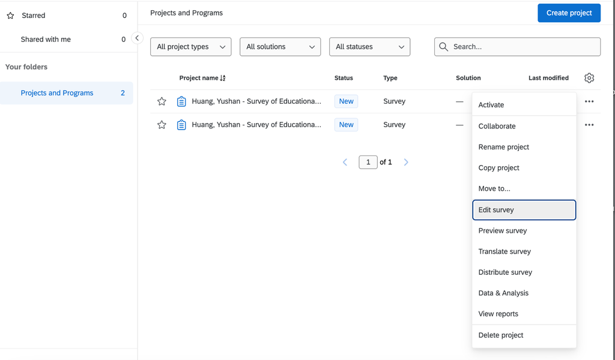

Project collaboration menu

*Figure 1. Qualtrics project menu showing the Collaborate option.*

### 2. Beginning of the rough draft

The preview shows the opening consent/introduction section and the Q1.1 response options.

[figure not shown]

Beginning of the Qualtrics survey

*Figure 2. Beginning of the rough draft, including the consent/introduction section.*

### 3. Middle of the rough draft

The preview shows Q2.4 and Q2.5 in the current rough draft.

[figure not shown]

Middle of the Qualtrics survey

*Figure 3. Middle portion of the rough draft.*

### 4. Current ending area of the rough draft

The preview shows Q2.11, the research-involvement matrix.

[figure not shown]

Current ending area of the Qualtrics survey

*Figure 4. Current ending area of the rough draft, showing Q2.11.*

## Reflection on the work completed so far

The rough-draft process helped me become more familiar with building survey questions in Qualtrics and matching a source questionnaire’s structure. I practiced selecting different question types, setting single-answer response formats, adding text entry to applicable “Other” choices, assigning recode values, applying skip logic, and using the preview function to visually check the survey.

At this stage, the survey is intentionally **not complete**, consistent with the module’s instruction that the rough draft may contain only part of the final survey. The completed portion currently reaches Q2.11.

## Submission status

| Item | Status |
| --- | --- |
| Rough Qualtrics survey created | Completed |
| Survey naming format | Completed |
| Questions built through Q2.11 | Completed |
| Recode values reflected where applicable | Completed |
| Skip logic for Q1.1 and Q1.2 | Completed |
| Preview screenshots captured | Completed |
| Project collaboration step documented | Screenshot included |
| Full survey through Q5.15 | Not yet completed; this checkpoint is a rough draft |

## Appendix

### Qualtrics Preview

[Open the current Qualtrics survey preview](https://cpp.pdx1.qualtrics.com/jfe/preview/previewId/d8792756-3bd2-47a5-b2c7-fa7128892c16/SV_8crbjiEfljPHcOy?Q_CHL=preview&Q_SurveyVersionID=current)